# glinski_metabolites

# tested hypotheses

- observed vivo versus in vitro degradation rates are the same, or observed vivo rates are lower than in vitro rates (due to other degradation processes, uptake kinetics?)
- first order kinetics are michaelis-menton, second order
- are in vitro indicative of in vivo

# things to do

- michaelis menton first order comparison for both experiments
- non-linear goodness of fit

# install and load supporting libraries

```
##
## 'drc' has been loaded.
```

```
## for references type 'citation()' and 'citation('drc')'.
```

# import experimental exposure and microsomal data

Load csv files with experimental data and microsome data sets. The beolw may return false but still be OK if rstudio does not have privileges to data directory (e.g., attached drive).

# experimental exposure data structure

Check out structure of imported data sets.

Set time and replicate fields as factors for later statistical inference.

# microsome experiment data structure

Check out structure of imported data set for the microsome analysis.

Set time and replicate fields as factors for later statistical inference.

# analyze microsomal data

The microsomal experiment has 3-4 replicates for each pesticide. The experiment progressively increases the concentration of the substrate (microMexp) and measures the enzyme velocity. At each substrate concentration the reaction is quenched after a specific period of time (0, 15, 30, 60, 90 mins). This time series data is used to estimate a slope associated with each substrate concentration. Substrate concentration and linear velocity slopes are then fit using Michaelis-Menten kinetics to estimate reaction rates for each pesticide.

# non-linear fitting

We use the dose-response model (drm) package from R for the fitting of the rate constant. We provide it the 2-parameter Michaelis-Menton function (mm2) as an argument. It uses the MM.2 function that is in the drc package and therefore is a drc object that contains a list of class drcMean, containing the mean function, the self starter function, the parameter names and other components such as derivatives and a function for calculating ED values. It is not shifted (??) so uses the fit f(x,(c,d,e)) = c + (d-c)/(1+e/x). Where x is the dose, it is a strictly increasing function so we reverse the sign of the slopes for the parents. e is the dose halfway between c and d, for the 2-parameter model c = 0.

```
## Michaelis-Menten
## (2 parameters)
## In 'drc':  MM.2
```

# atrazine

```
## [1] "Substrates:"
```

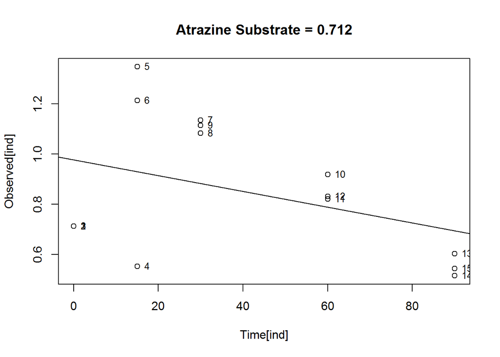

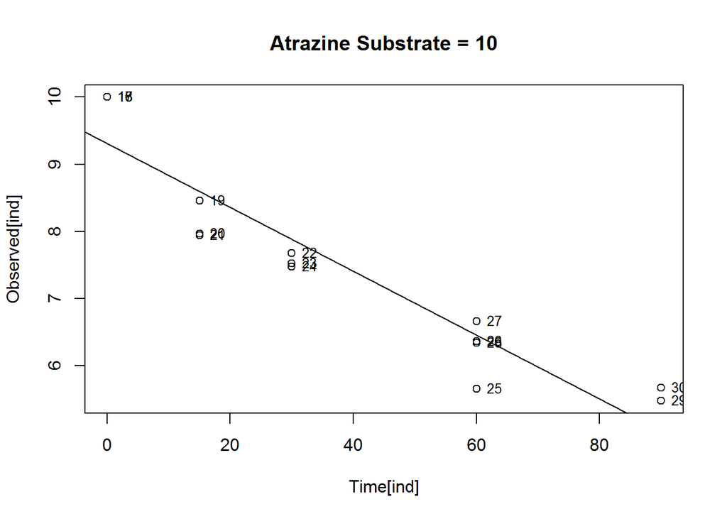

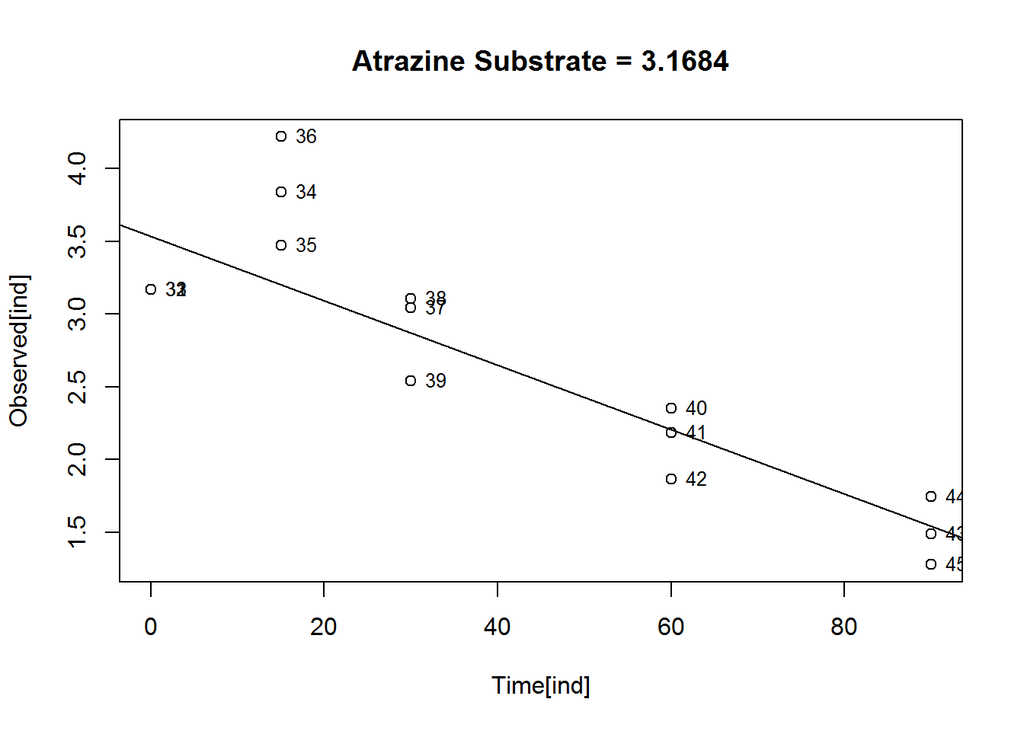

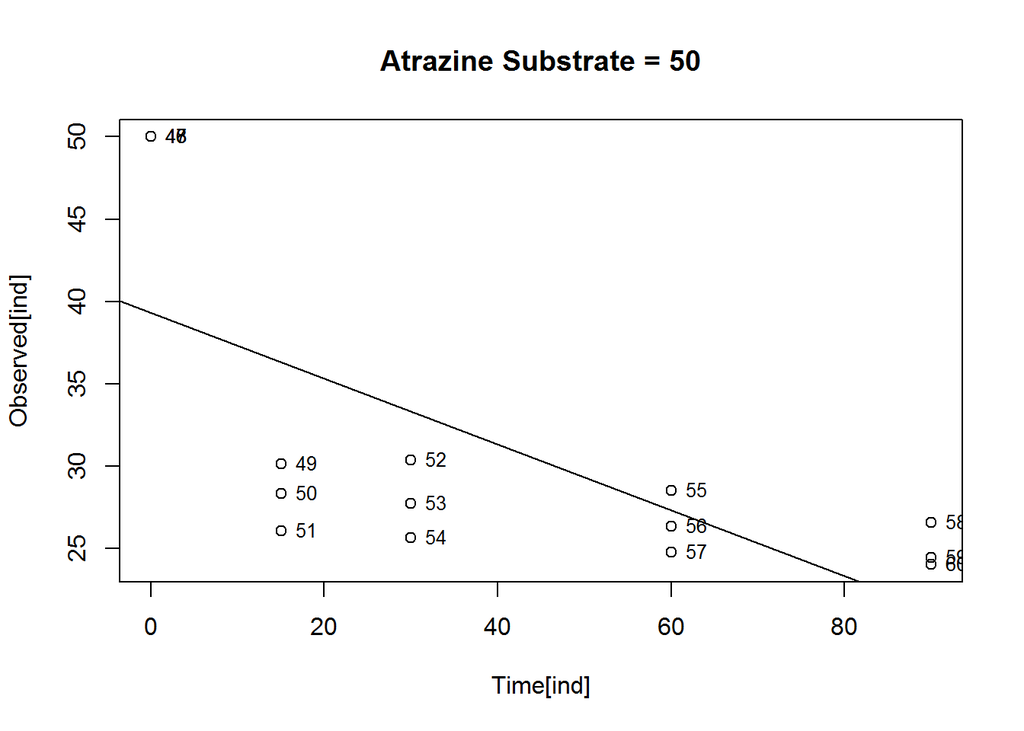

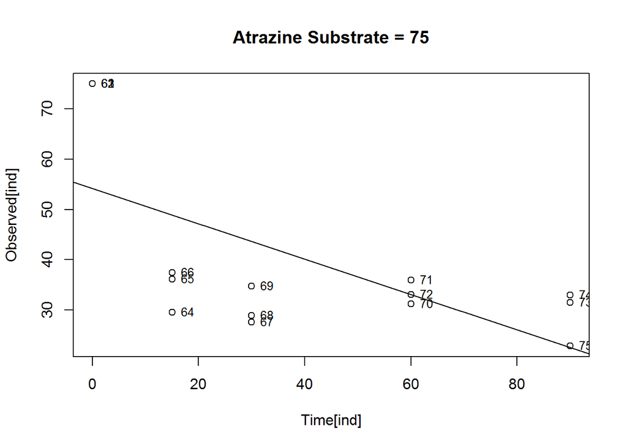

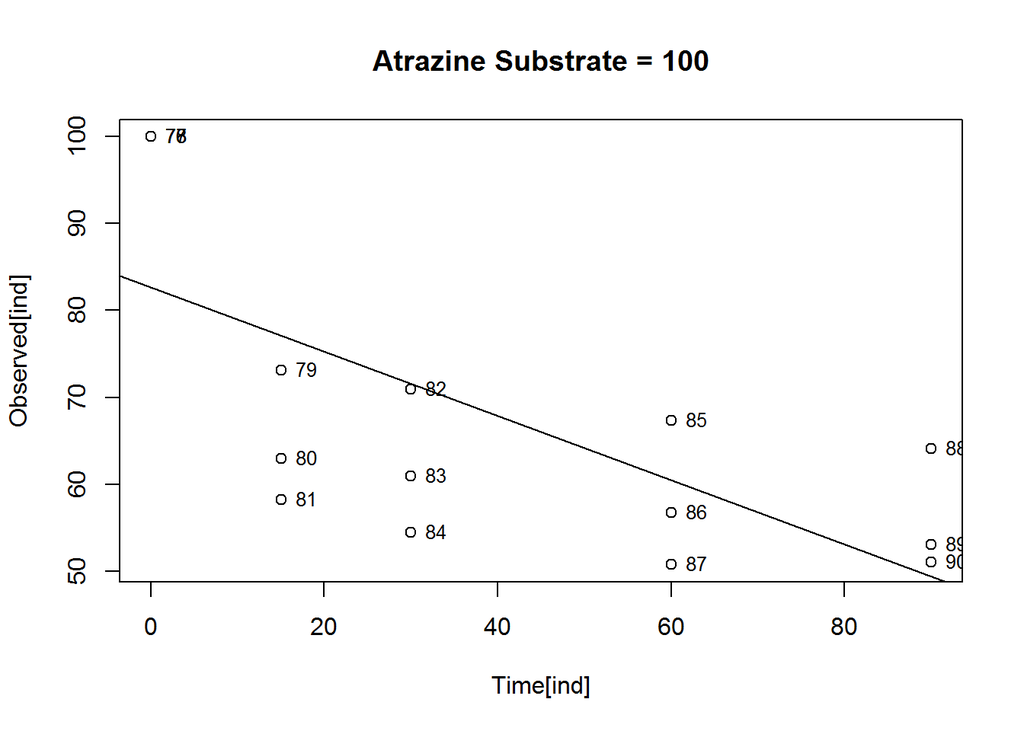

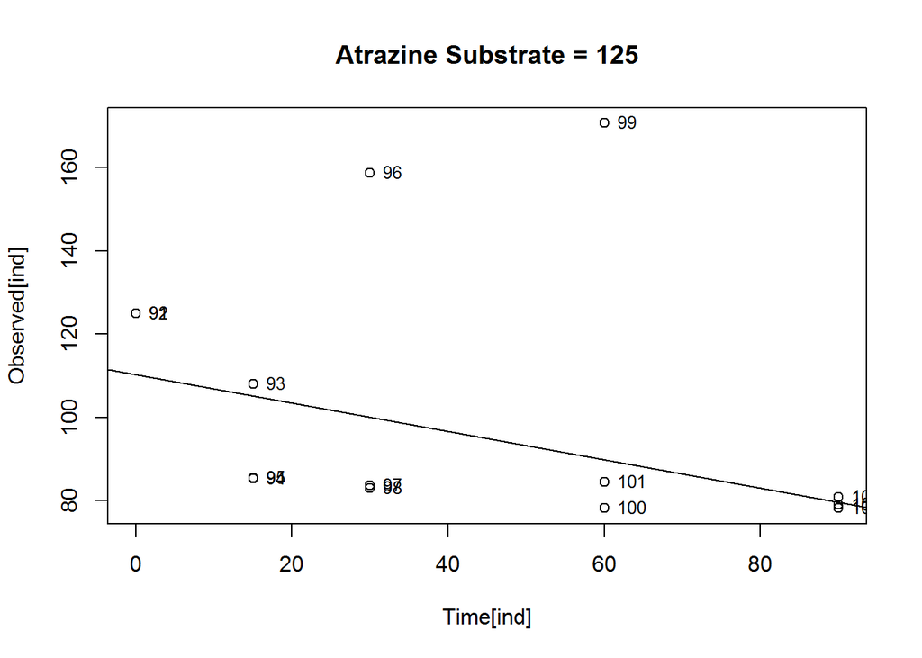

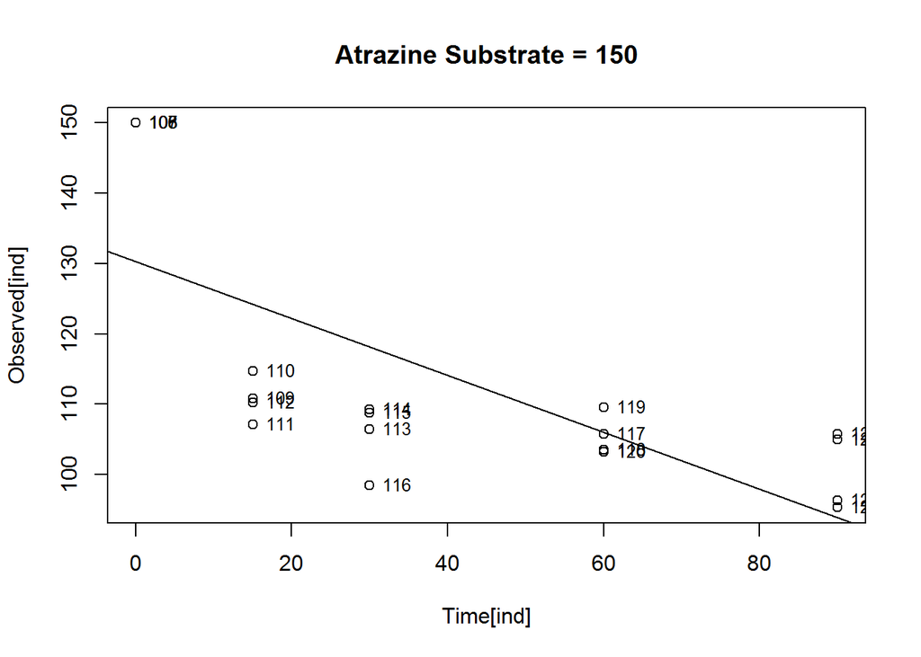

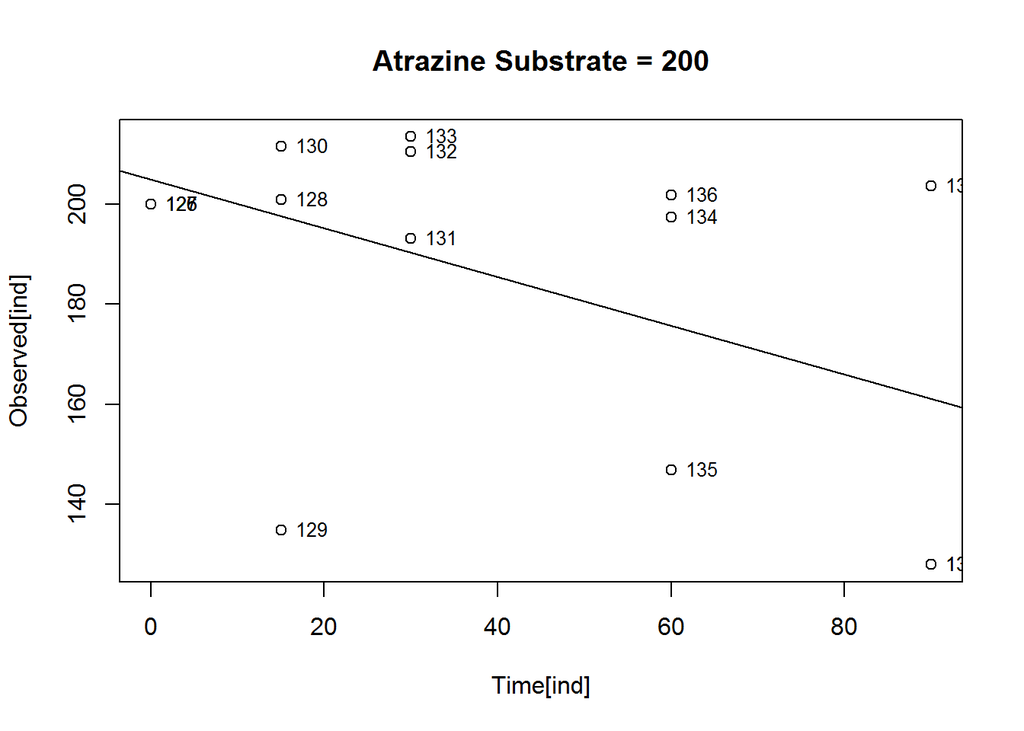

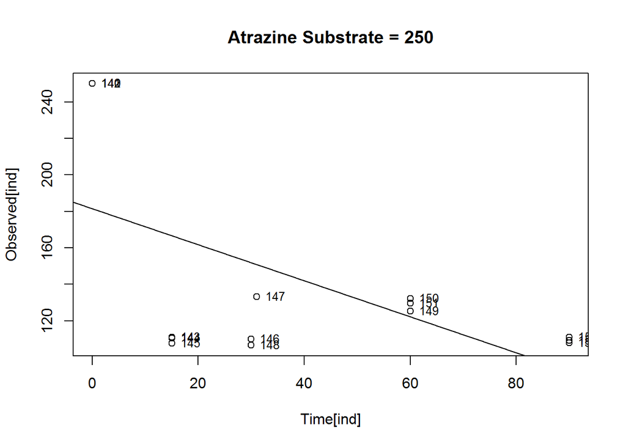

```
## [1] "here are the rates"
```

```
##
## Model fitted: Michaelis-Menten (2 parms)
##
## Parameter estimates:
##
##                 Estimate Std. Error    t-value p-value
## d:(Intercept) 1.1876e+05 2.9124e+05 4.0776e-01  0.6941
## e:(Intercept) 7.0431e+03 1.7723e+04 3.9740e-01  0.7015
##
## Residual standard error:
##
##  513.6882 (8 degrees of freedom)
```

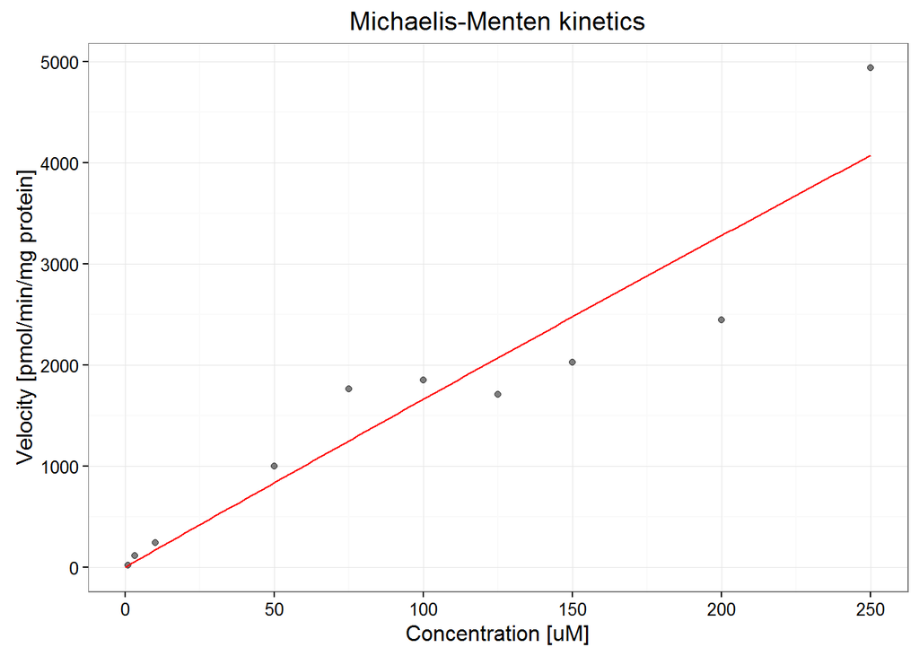

We are interested in the reaction rate, v, which is a function of available substrate (pesticide) and the presence of an enzyme. We get Vmax from the asymptote and K = 0.5*Vmax. Biochemical reactions with a single substrate are typically assumed to follow Michaelis-Menten kinetics even if they deviate from the basic model assumptions.

We are fitting the 2-parameter model.

Used to estimate slopes.

# dea

```
## [1] "Substrates:"
```

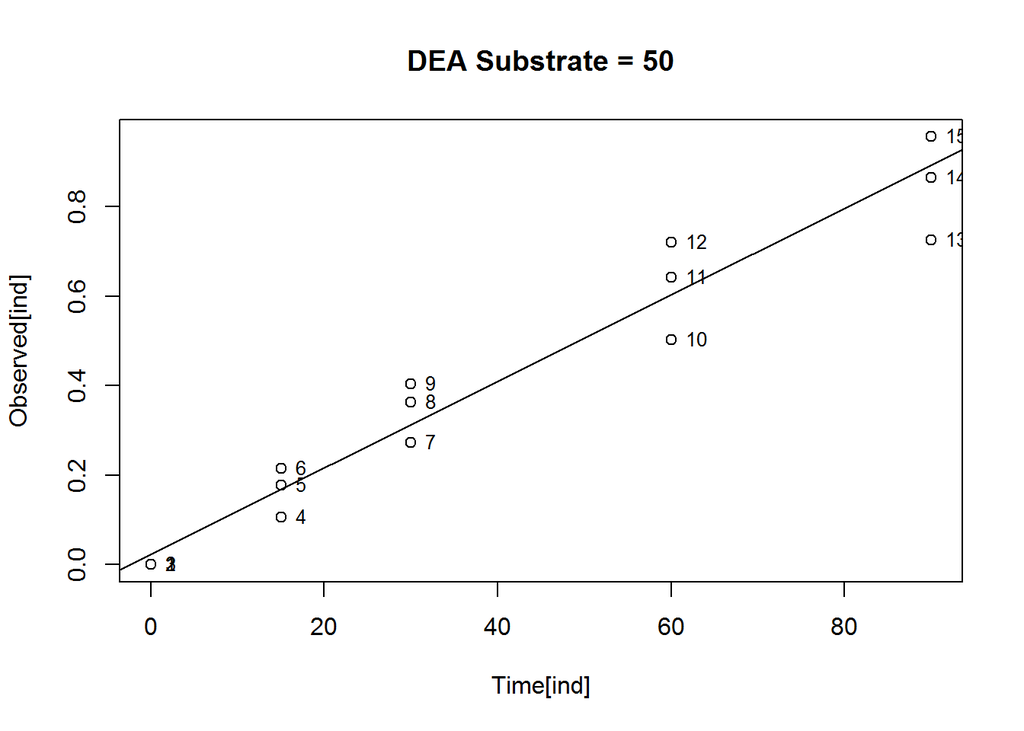

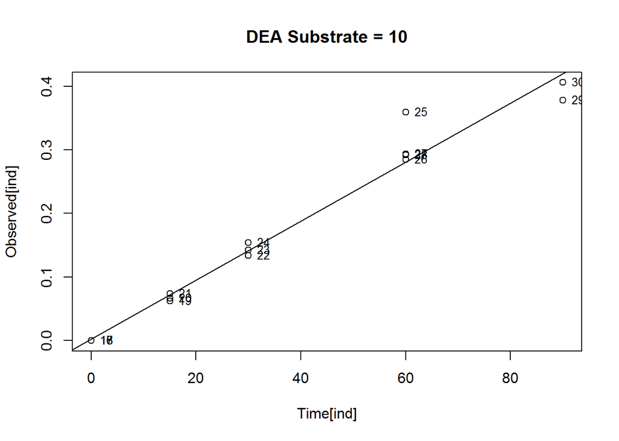

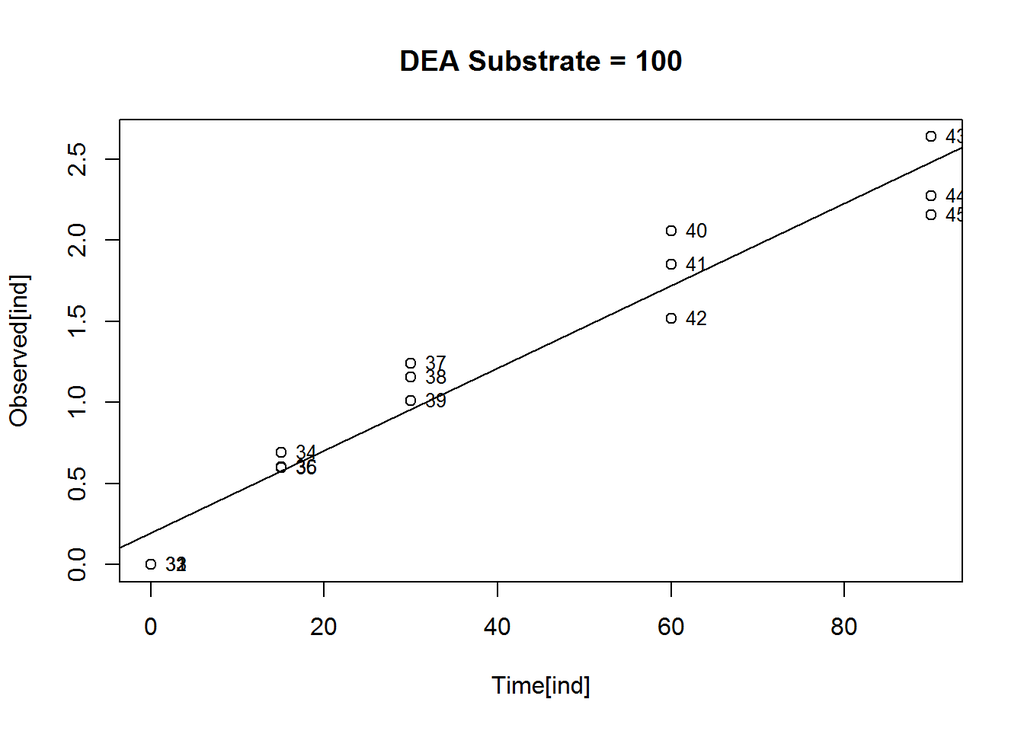

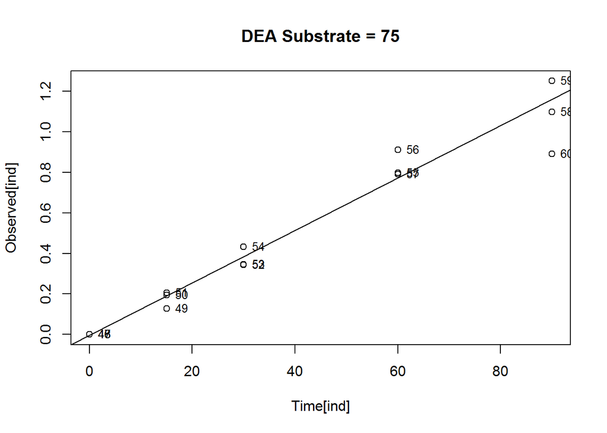

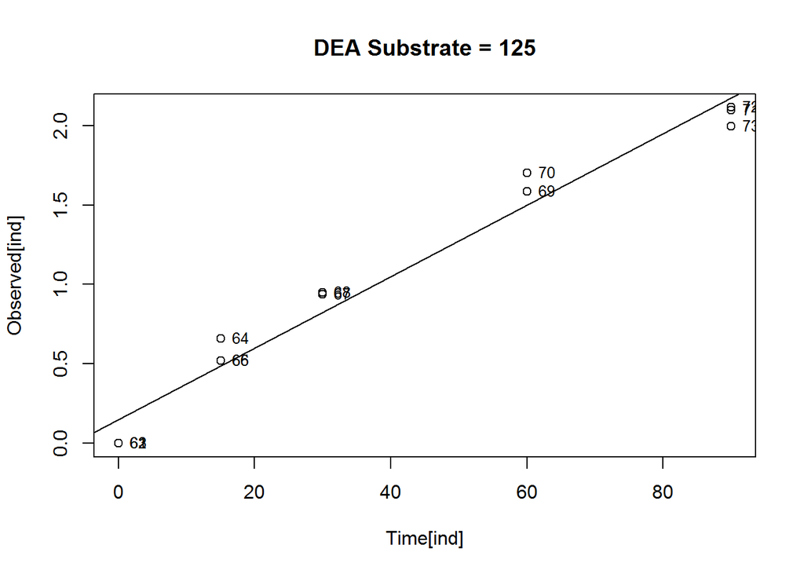

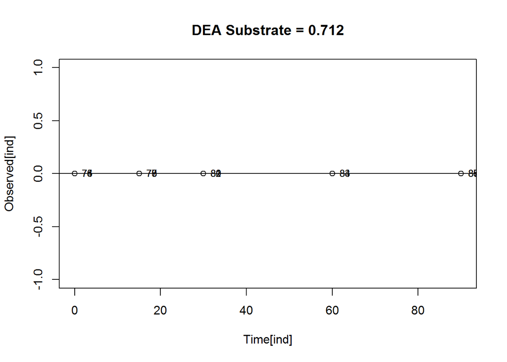

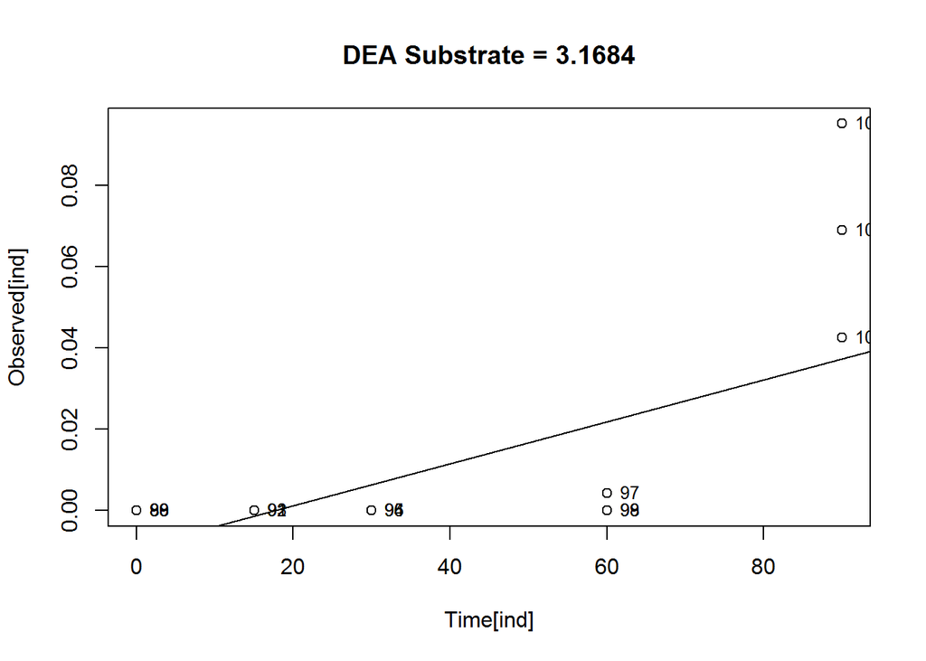

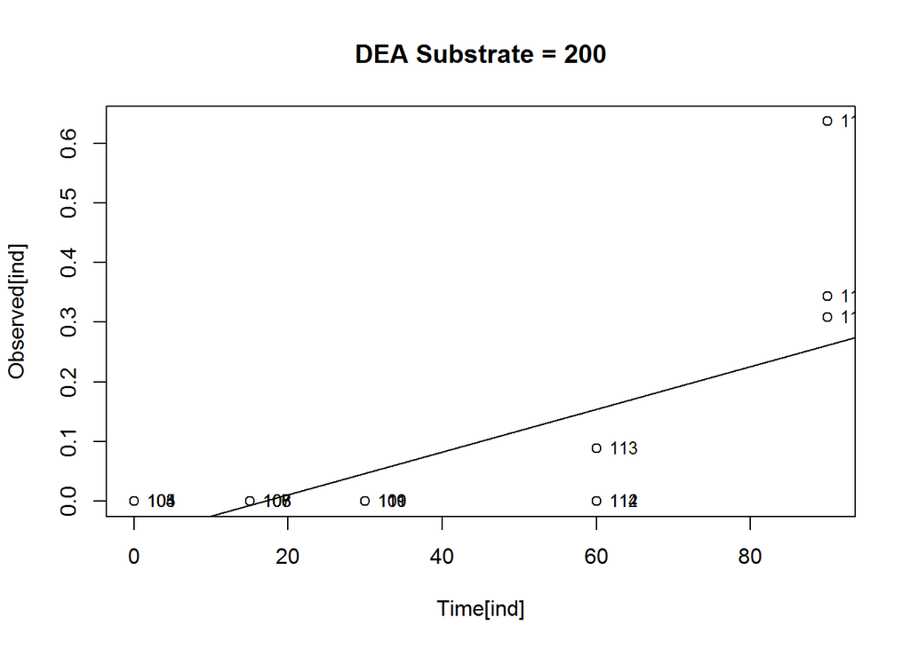

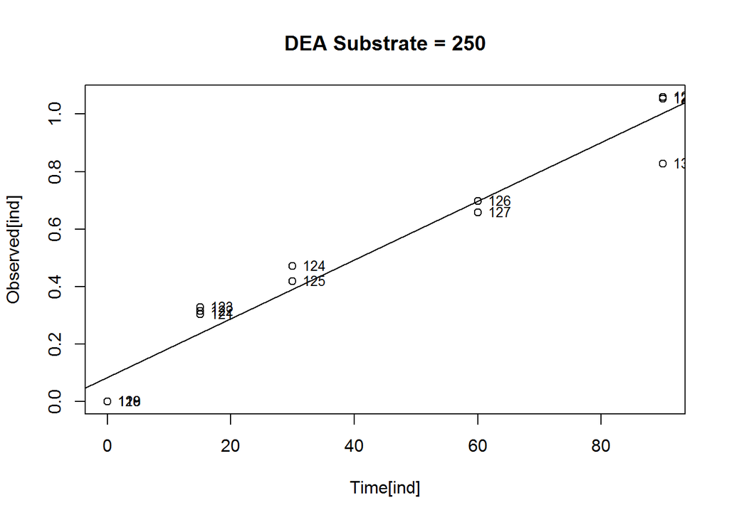

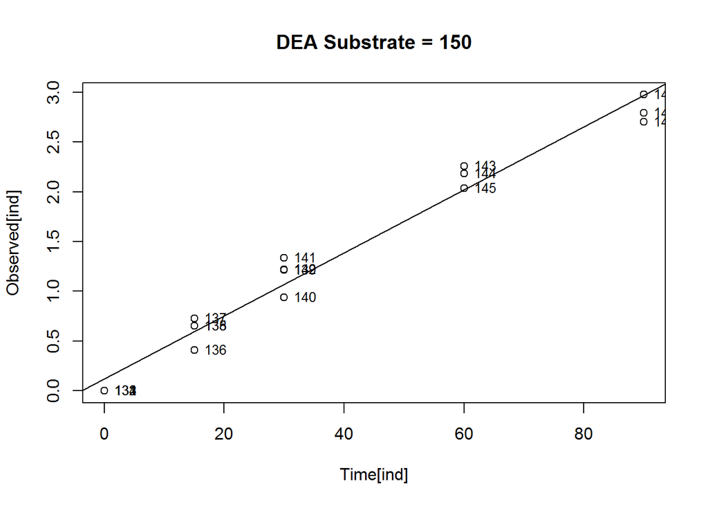

```
## [1] "here are the rates"
```

```
##
## Model fitted: Michaelis-Menten (2 parms)
##
## Parameter estimates:
##
##               Estimate Std. Error  t-value p-value
## d:(Intercept) 97.64281   29.77021  3.27988  0.0112
## e:(Intercept) 21.13369   29.70447  0.71146  0.4970
##
## Residual standard error:
##
##  44.01437 (8 degrees of freedom)
```

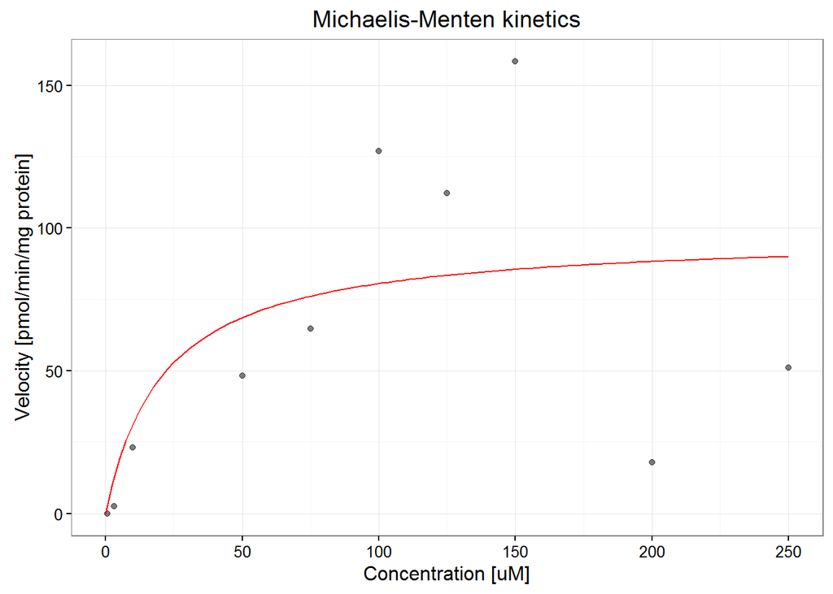

We are interested in the reaction rate, v, which is a function of available substrate (pesticide) and the presence of an enzyme. We get Vmax from the asymptote and K = 0.5*Vmax. Biochemical reactions with a single substrate are typically assumed to follow Michaelis-Menten kinetics even if they deviate from the basic model assumptions.

We are fitting the 2-parameter model.

Used to estimate slopes.

# dia

```
## [1] "Substrates:"
```

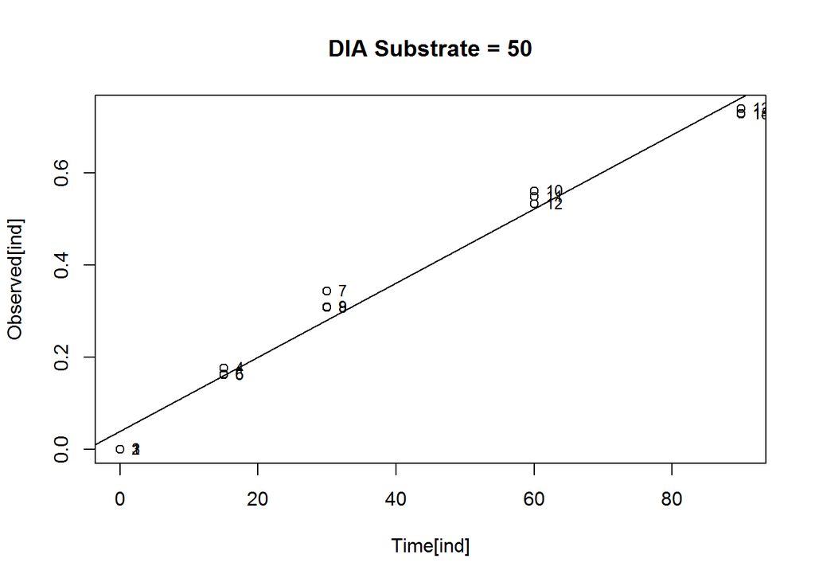

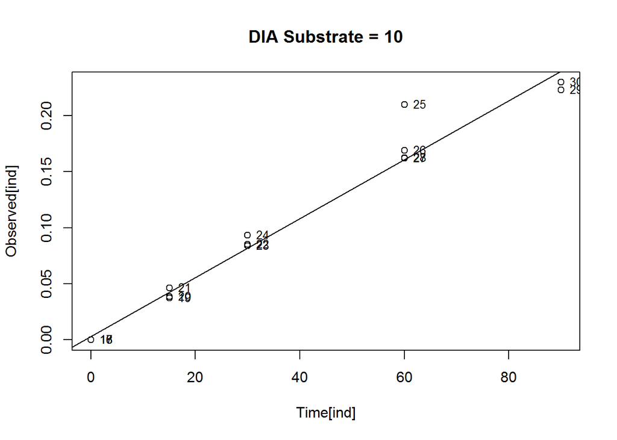

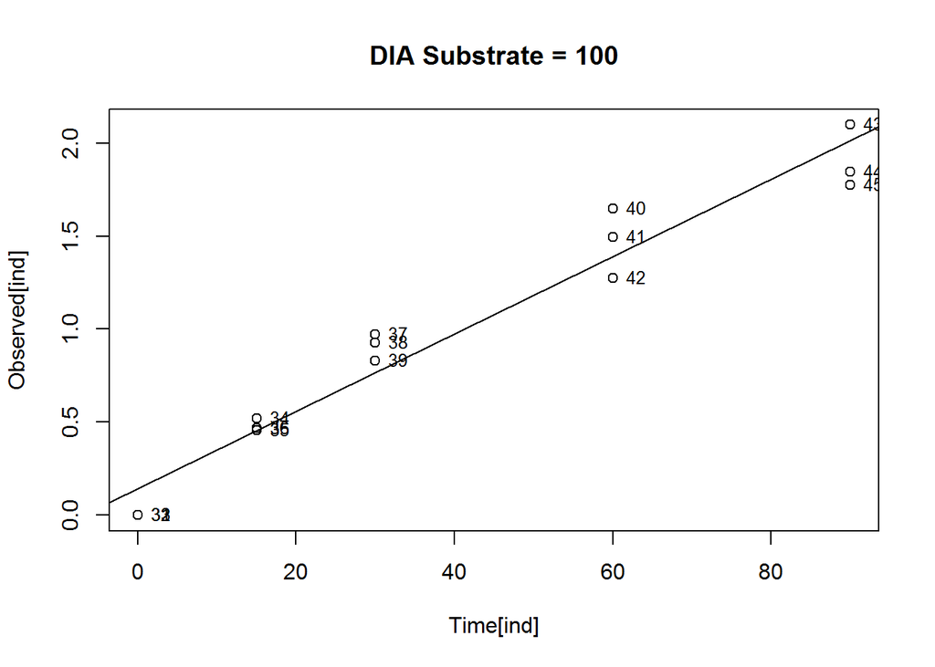

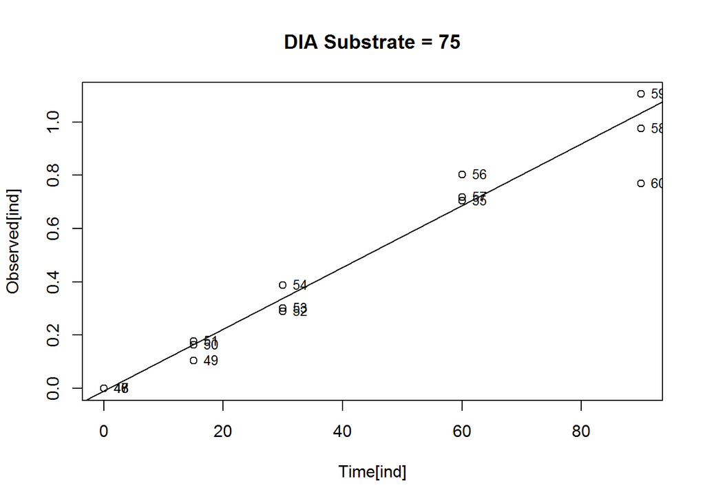

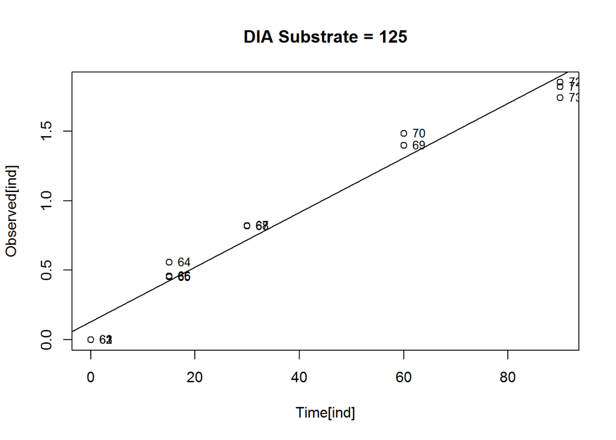

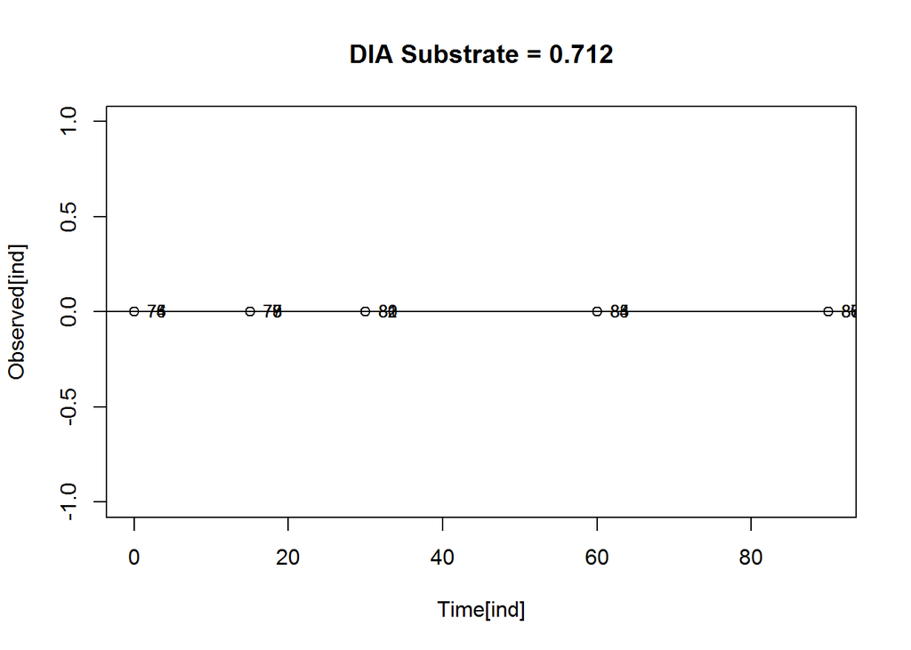

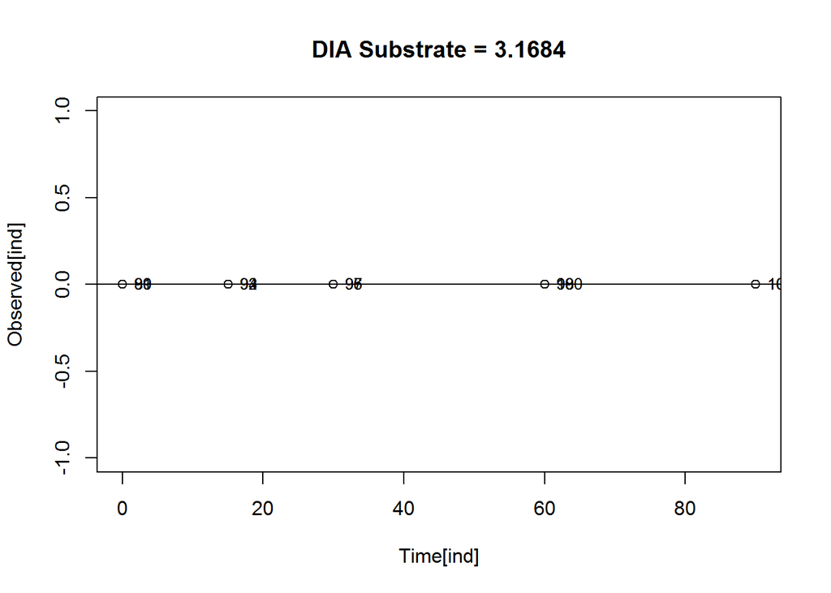

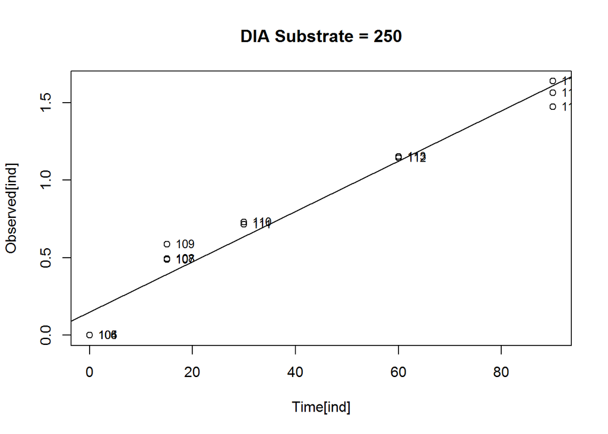

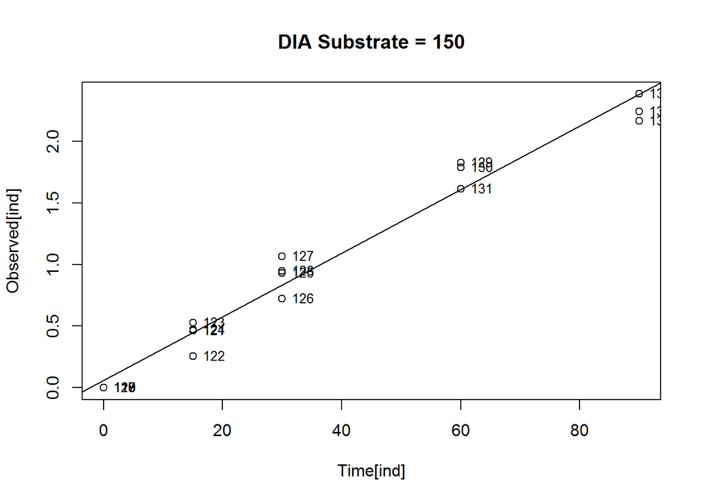

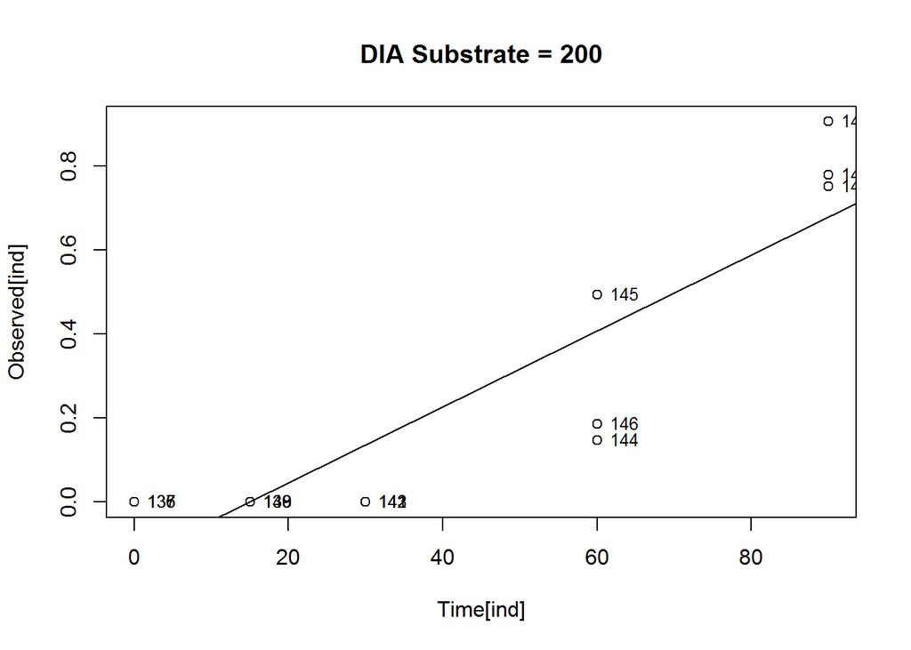

```
## [1] "here are the rates"
```

```
##
## Model fitted: Michaelis-Menten (2 parms)
##
## Parameter estimates:
##
##               Estimate Std. Error  t-value p-value
## d:(Intercept) 110.1071    29.6962   3.7078  0.0060
## e:(Intercept)  44.4716    40.7922   1.0902  0.3074
##
## Residual standard error:
##
##  26.75434 (8 degrees of freedom)
```

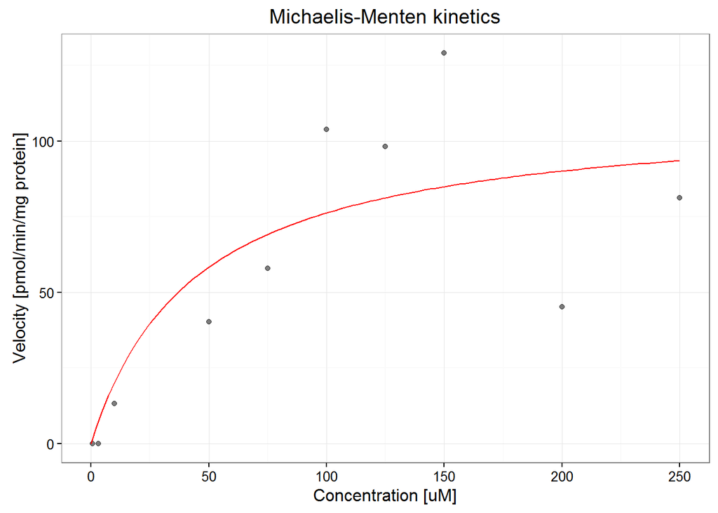

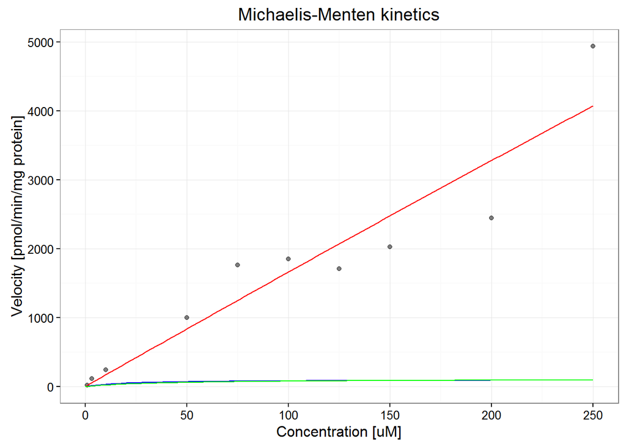